# Cocktail ingredients

2020-05-26

## Introducción

Hola muchachos en esta oportunidad voy a trabajar con un paquete nuevo para este tidytuesday y es `tidylo`, el cual permite calcular la probabilidad de tener un registro a través del método de **Monroe** el cual permite calcular las probabilidades de registro de un documento a través de una particularidad, de un lag (registro previo). Dicho lo anterior tocaré uno de los temas que más me apaciona y es el empirismo bayesiano!

Con `tidylo` podremos calcular la probabilidad de un registro a través de diferentes implementaciones a través de unas carácteristicas de recuentos (samples).

Dicho lo anterior en este análisis me enfocare en lo siguiente :

- ¿Qué tipos de ingredientes se usan para ciertas bebidas?
- ¿Qué tipo de vasos?
- ¿Qué tipo de ingredientes se usan en un tipo especifico de vaso?

Acá hay una gran oportunidad para hacer uso de los PCA`s y algunas otras tecnicas que permitan hacer un análisis más profundo.

## EDA

Veamos de primera mano que información trae este set de datos

```r
cocktails%>%
  head()
```

```
## # A tibble: 6 x 13
##   row_id drink date_modified       id_drink alcoholic category drink_thumb glass
##    <dbl> <chr> <dttm>                 <dbl> <chr>     <chr>    <chr>       <chr>
## 1      0 '57 … 2016-07-18 22:49:04    14029 Alcoholic Cocktail http://www… High…
## 2      0 '57 … 2016-07-18 22:49:04    14029 Alcoholic Cocktail http://www… High…
## 3      1 1-90… 2016-07-18 22:27:04    15395 Alcoholic Shot     http://www… Old-…
## 4      1 1-90… 2016-07-18 22:27:04    15395 Alcoholic Shot     http://www… Old-…
## 5      1 1-90… 2016-07-18 22:27:04    15395 Alcoholic Shot     http://www… Old-…
## 6      1 1-90… 2016-07-18 22:27:04    15395 Alcoholic Shot     http://www… Old-…
## # … with 5 more variables: iba <chr>, video <lgl>, ingredient_number <dbl>,
## #   ingredient <chr>, measure <chr>
```

Viendo esta data lo primero que se me ocurre trabajar es ver como es el comportamiento de los ingredientes y con base a ello intentar plantear los pasos necesarios para responder las preguntas que estan en el intro de este post

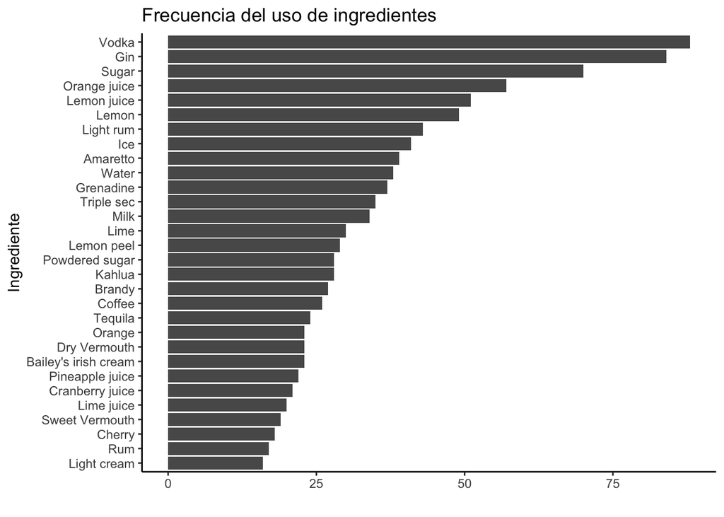

```r
cocktails%>%
  count(ingredient,sort = TRUE)%>%
  mutate(ingredient=fct_reorder(ingredient,n))%>%
  head(30)%>%
  ggplot(aes(ingredient,n))+
  geom_col(show.legend = FALSE)+
  coord_flip()+
  labs(x='Ingrediente',
       y='',
       title= 'Frecuencia del uso de ingredientes')
```

Me parece interesante que el vodka sea el más usado para hacer cocletes, seguro un conocedor del tema resaltaría su versatilidad. Ahora veamos más al detalle sobre que tipo de bebidas se usan estos ingredientes

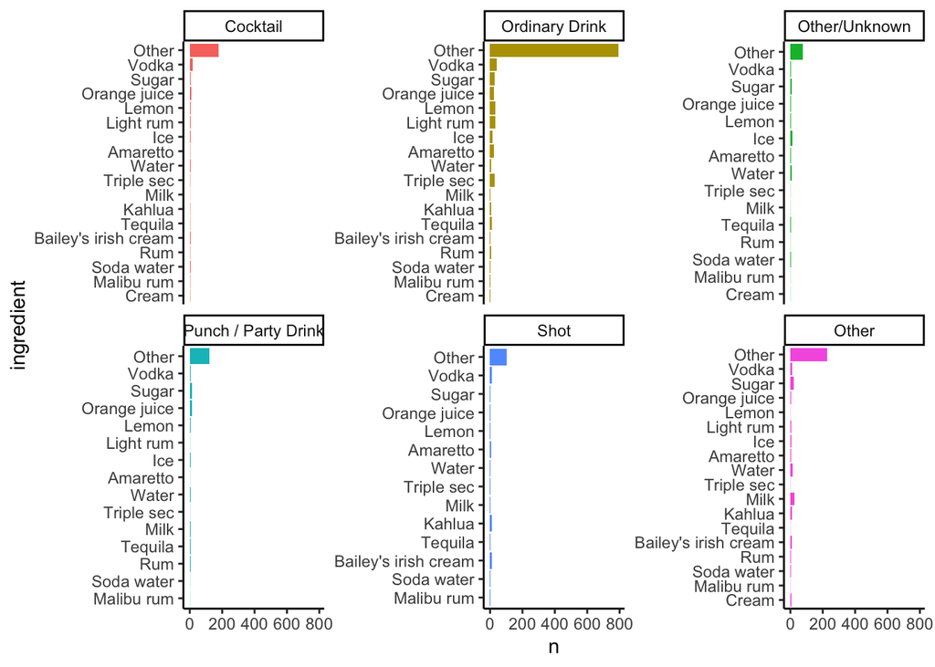

```r
cocktails%>%
  count(category,ingredient,sort = TRUE)%>%
  mutate(category=fct_lump(category,5),
         ingredient=fct_lump(ingredient,10))%>%
  mutate(ingredient=fct_reorder(ingredient,n,sum))%>%
  ungroup()%>%
  ggplot(aes(ingredient,n,fill=category))+
  geom_col(show.legend = FALSE)+
  facet_wrap(~category,scales = 'free_y')+
  coord_flip()
```

El valor `other` no dice mucho, por lo tanto lo eliminaré para poder hacer un análisis más exacto y organizaré las barras a través de `tidytext`

```r
cocktails%>%
  count(ingredient,sort = TRUE)%>%
  filter(str_detect(ingredient,"O"))
```

```
## # A tibble: 12 x 2
##    ingredient         n
##    <chr>          <int>
##  1 Orange juice      57
##  2 Orange            23
##  3 Orange bitters    12
##  4 Orange peel        5
##  5 Olive              4
##  6 Orange Juice       3
##  7 Orange spiral      2
##  8 Orgeat syrup       2
##  9 Ouzo               2
## 10 Olive Brine        1
## 11 Orange Curacao     1
## 12 Oreo cookie        1
```

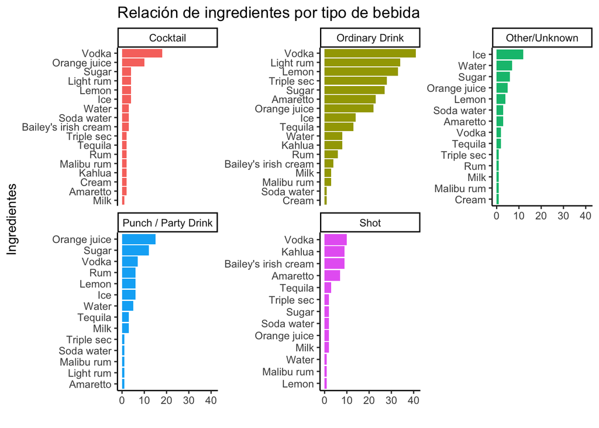

```r
cocktails%>%
  count(category,ingredient,sort = TRUE)%>%
  mutate(category=fct_lump(category,5),
         ingredient=fct_lump(ingredient,10))%>%
  mutate(ingredient=fct_reorder(ingredient,n,sum))%>%
  filter(category!='Other')%>%
  filter(ingredient!='Other')%>%
  mutate(ingredient=reorder_within(ingredient,n,category))%>%
  ggplot(aes(ingredient,n,fill=category))+
  geom_col(show.legend = FALSE)+
  coord_flip()+
  facet_wrap(~category,scales = 'free_y')+
  scale_x_reordered()+
  labs(x='Ingredientes',
       y='',
       title = 'Relación de ingredientes por tipo de bebida')
```

Acá hay una información bastante interesante, dado que se perfilan varios tipos de bebidas como bases, por decirlo de está manera para cada uno de los cocteles. Para comprender de manera más oportuna esto se debe saber es ¿cuál de los ingredientes tiende a aparecer siempre? y ¿Cuáles aparecen como mezcla?

```r
ingredientes_pares<-cocktails%>%
  add_count(ingredient)%>%
  filter(n>=20)%>%
  pairwise_cor(ingredient,category,sort=TRUE)
ingredientes_pares%>%
  head(15)
```

```
## # A tibble: 15 x 3
##    item1                item2                correlation
##    <chr>                <chr>                      <dbl>
##  1 Water                Sugar                      1.
##  2 Sugar                Water                      1.
##  3 Dry Vermouth         Gin                        1
##  4 Lime                 Lime juice                 1
##  5 Gin                  Dry Vermouth               1
##  6 Lime juice           Lime                       1
##  7 Lemon                Cranberry juice            0.833
##  8 Lemon                Lemon juice                0.833
##  9 Cranberry juice      Lemon                      0.833
## 10 Lemon juice          Lemon                      0.833
## 11 Bailey's irish cream Kahlua                     0.828
## 12 Kahlua               Bailey's irish cream       0.828
## 13 Pineapple juice      Cranberry juice            0.828
## 14 Cranberry juice      Pineapple juice            0.828
## 15 Lime juice           Lemon juice                0.828
```

Hay correlaciones ineresantes, pero me voy a enfocar en dos particulares que llamaron mi atención, la del **Gin** y la del **Lemon**

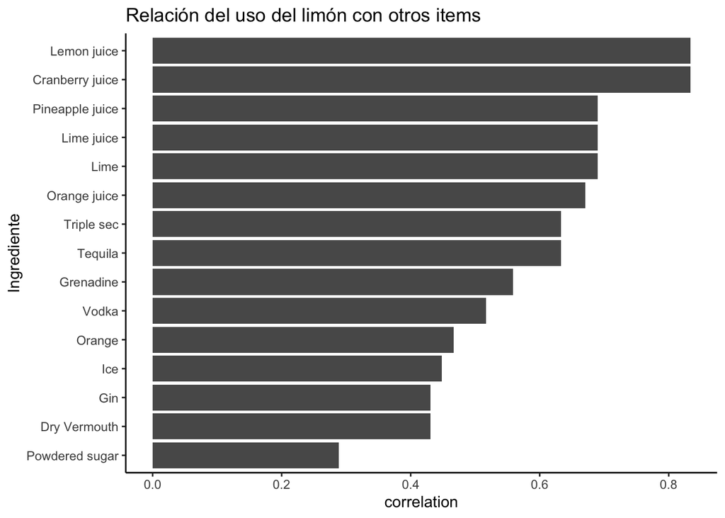

```r
ingredientes_pares%>%
  filter(item1=='Lemon')%>%
  head(15)%>%
  ggplot(aes(fct_reorder(item2,correlation),correlation))+
  geom_col()+
  coord_flip()+
  labs(x='Ingrediente',
       title='Relación del uso del limón con otros items')
```

Acá lo que podemos ver es que la relación del limón con el Gin es bastante baja, pero con otros acidos va bastante bien!!

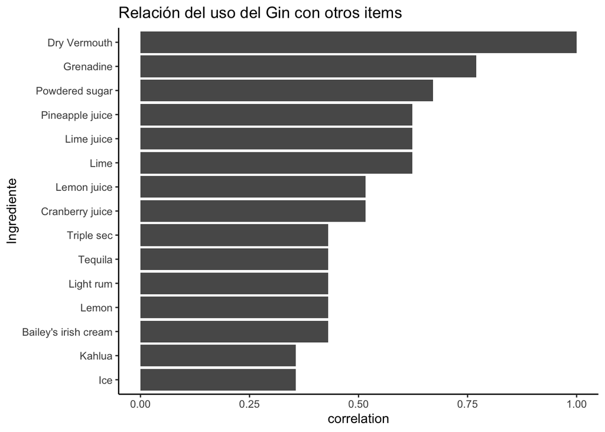

```r
ingredientes_pares%>%
  filter(item1=='Gin')%>%
  head(15)%>%
  ggplot(aes(fct_reorder(item2,correlation),correlation))+
  geom_col()+
  coord_flip()+
  labs(x='Ingrediente',
       title='Relación del uso del Gin con otros items')
```

Versus el Gin que va de maravillas con cosas dulces.